# RMarkdown DSC 520 - Project

Pushkar Chougule

Nov 20th 2020

## R Markdown

```r
library(ggplot2)

library(car)
```

**initial reading of California Housing prices csv**

```
## 'data.frame':    20640 obs. of  10 variables:
##  $ longitude         : num  -122 -122 -122 -122 -122 ...
##  $ latitude          : num  37.9 37.9 37.9 37.9 37.9 ...
##  $ housing_median_age: num  41 21 52 52 52 52 52 52 42 52 ...
##  $ total_rooms       : num  880 7099 1467 1274 1627 ...
##  $ total_bedrooms    : num  129 1106 190 235 280 ...
##  $ population        : num  322 2401 496 558 565 ...
##  $ households        : num  126 1138 177 219 259 ...
##  $ median_income     : num  8.33 8.3 7.26 5.64 3.85 ...
##  $ median_house_value: num  452600 358500 352100 341300 342200 ...
##  $ ocean_proximity   : Factor w/ 5 levels "<1H OCEAN","INLAND",..: 4 4 4 4 4 4 4 4 4 4 ...
```

**histograms and scatter plots for initial analysis**

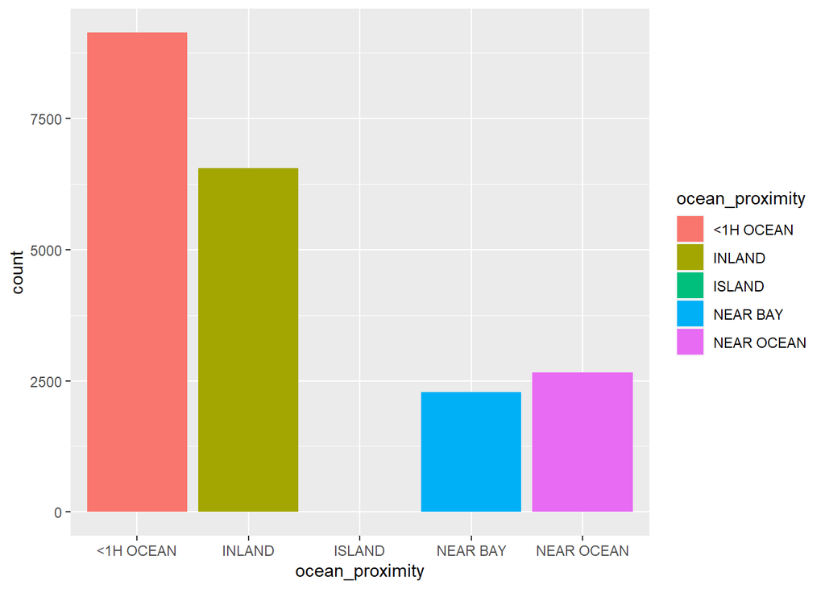

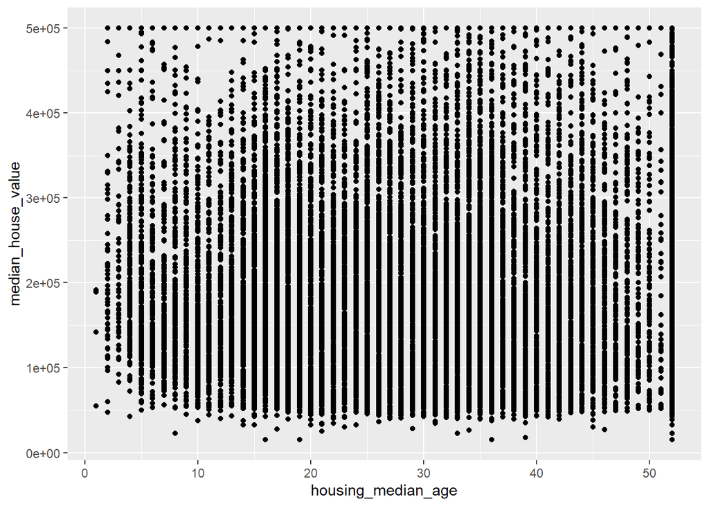

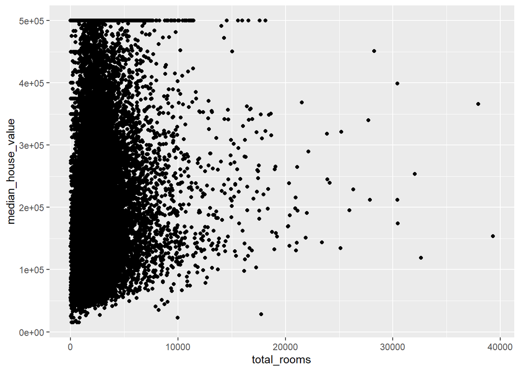

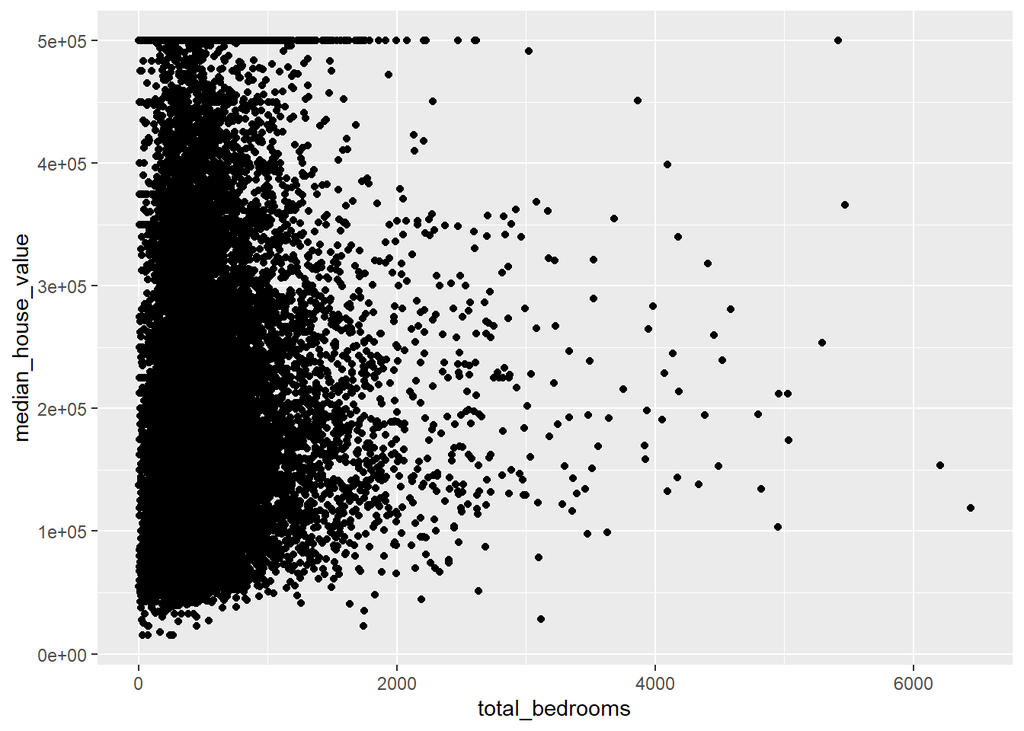

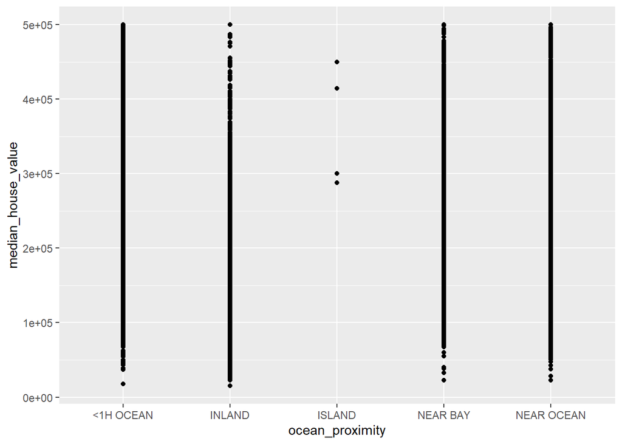

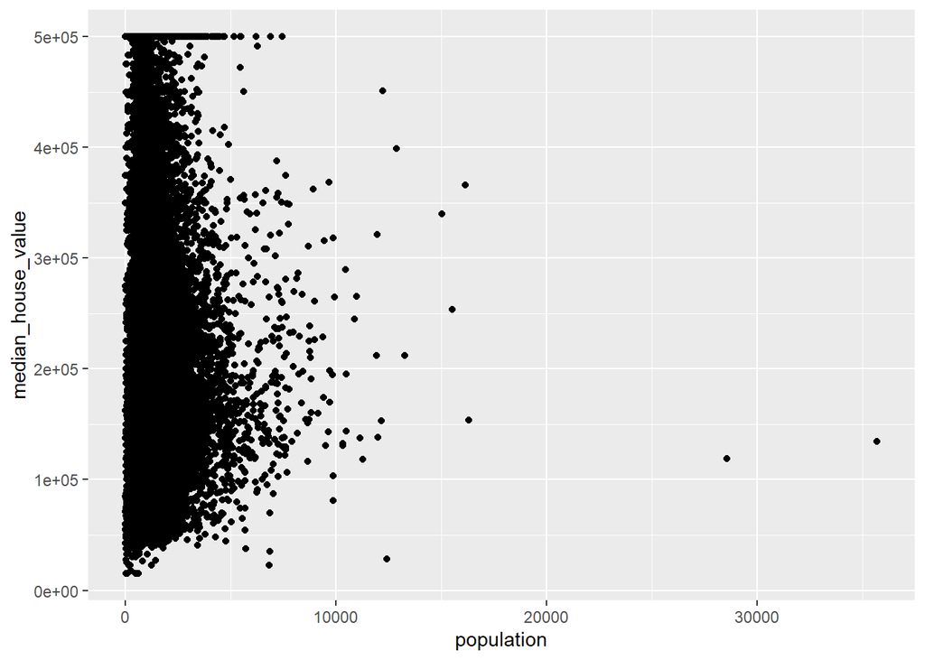

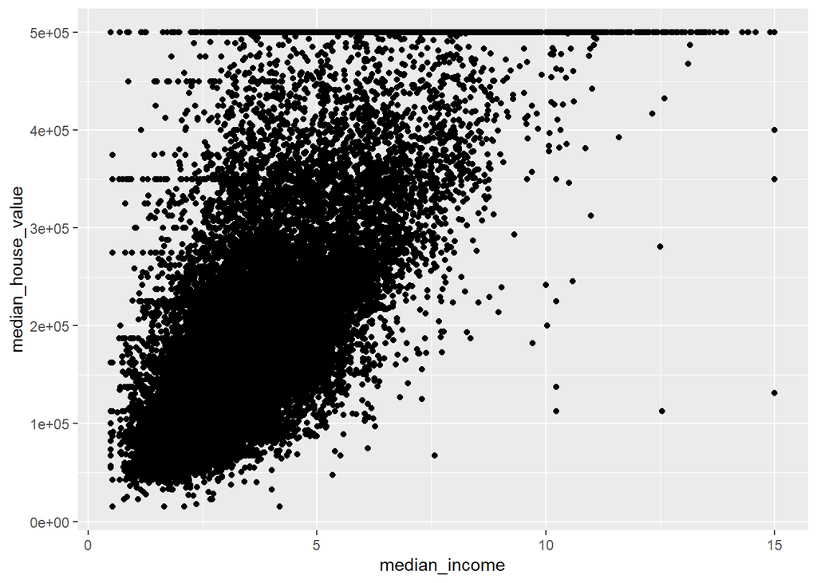

> 1. There are 5 distinct categories in the ocean proximity variables
> 2. Housing median age vs. median house value scatter plot
> 3. scatter plot for total rooms vs. median house value
> 4. scatter plot for total bedrooms vs. median house value
> 5. Median House value price ranges are similar in each of the ocean proximity category, looking at the scatter plot
> 6. scatter plot for population vs median house value
> 7. median income vs median house value

**initial reading of London Housing prices csv**

```
## 'data.frame':    3480 obs. of  6 variables:
##  $ Price         : int  1675000 650000 735000 1765000 675000 420000 1475000 650000 2500000 925000 ...
##  $ House_Type    : Factor w/ 8 levels "Bungalow","Duplex",..: 4 3 3 4 3 3 4 6 4 3 ...
##  $ Area_sqft     : int  2716 814 761 1986 700 403 1548 560 1308 646 ...
##  $ Num_Bedrooms  : int  5 2 2 4 2 1 4 1 3 2 ...
##  $ Num_Bathrooms : int  5 2 2 4 2 1 4 1 3 2 ...
##  $ Num_Receptions: int  5 2 2 4 2 1 4 1 3 2 ...
```

**London housing data initial analysis histogram**

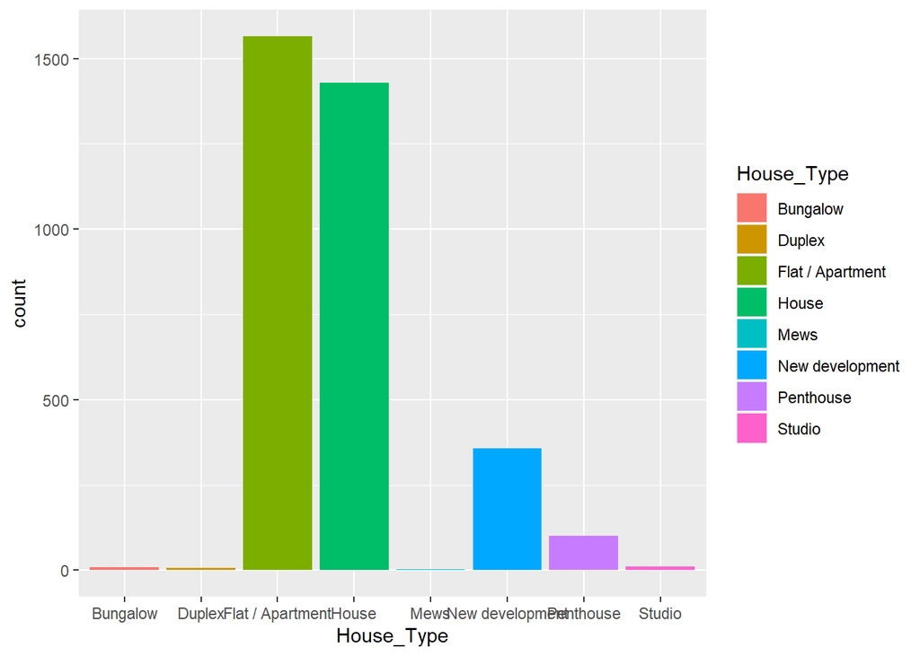

**initial reading of US Housing prices csv file and summary**

```
##    MSSubClass     MSZoning     LotFrontage        LotArea         BldgType
##  20     :536   C (all):  10   Min.   :  0.00   Min.   :  1300   1Fam  :1220
##  60     :299   FV     :  65   1st Qu.: 42.00   1st Qu.:  7554   2fmCon:  31
##  50     :144   RH     :  16   Median : 63.00   Median :  9478   Duplex:  52
##  120    : 87   RL     :1151   Mean   : 57.62   Mean   : 10517   Twnhs :  43
##  30     : 69   RM     : 218   3rd Qu.: 79.00   3rd Qu.: 11602   TwnhsE: 114
##  160    : 63                  Max.   :313.00   Max.   :215245
##  (Other):262
##    HouseStyle   LotConfig         Neighborhood        Condition1
##  1Story :726   Length:1460        Length:1460        Length:1460
##  2Story :445   Class :character   Class :character   Class :character
##  1.5Fin :154   Mode  :character   Mode  :character   Mode  :character
##  SLvl   : 65
##  SFoyer : 37
##  1.5Unf : 14
##  (Other): 19
##   Condition2         Foundation         RoofStyle           RoofMatl
##  Length:1460        Length:1460        Length:1460        Length:1460
##  Class :character   Class :character   Class :character   Class :character
##  Mode  :character   Mode  :character   Mode  :character   Mode  :character
##
##
##
##
##  Exterior1st        Exterior2nd         ExterQual          HeatingQC
##  Length:1460        Length:1460        Length:1460        Length:1460
##  Class :character   Class :character   Class :character   Class :character
##  Mode  :character   Mode  :character   Mode  :character   Mode  :character
##
##
##
##
##   Electrical         OverallQual   OverallCond    YearBuilt     YearRemodAdd
##  Length:1460        5      :397   5      :821   Min.   :1872   Min.   :1950
##  Class :character   6      :374   6      :252   1st Qu.:1954   1st Qu.:1967
##  Mode  :character   7      :319   7      :205   Median :1973   Median :1994
##                     8      :168   8      : 72   Mean   :1971   Mean   :1985
##                     4      :116   4      : 57   3rd Qu.:2000   3rd Qu.:2004
##                     9      : 43   3      : 25   Max.   :2010   Max.   :2010
##                     (Other): 43   (Other): 28
```

[output cut: 25 more lines]

```
##  Min.   :0.000   Min.   : 2.000   Min.   :   0.0   GdPrv:  59
##  1st Qu.:2.000   1st Qu.: 5.000   1st Qu.: 334.5   GdWo :  54
##  Median :3.000   Median : 6.000   Median : 480.0   MnPrv: 157
##  Mean   :2.866   Mean   : 6.518   Mean   : 473.0   MnWw :  11
##  3rd Qu.:3.000   3rd Qu.: 7.000   3rd Qu.: 576.0   NA's :1179
##  Max.   :8.000   Max.   :14.000   Max.   :1418.0
##
##    SalePrice
##  Min.   : 34900
##  1st Qu.:129975
##  Median :163000
##  Mean   :180921
##  3rd Qu.:214000
##  Max.   :755000
##
```

> US Housing prices dataset has plenty of variables (81 in all) and hence I will be using this dataset for my analysis purpose. I have manually looked at the data variables and also used some of the plots to understand the data points / variables. I have tried to capture this information below. Noticed that TotalBsmtSF is the addition of BsmtFinSF1, BsmtFinSF2 and BsmtUnfSF. Similarly 1stFlrSF and 2ndFlrSF columns values are combined into and it is present in variable GrLivArea.

**histogram plots for initial analysis of data to also help with data cleanup steps**

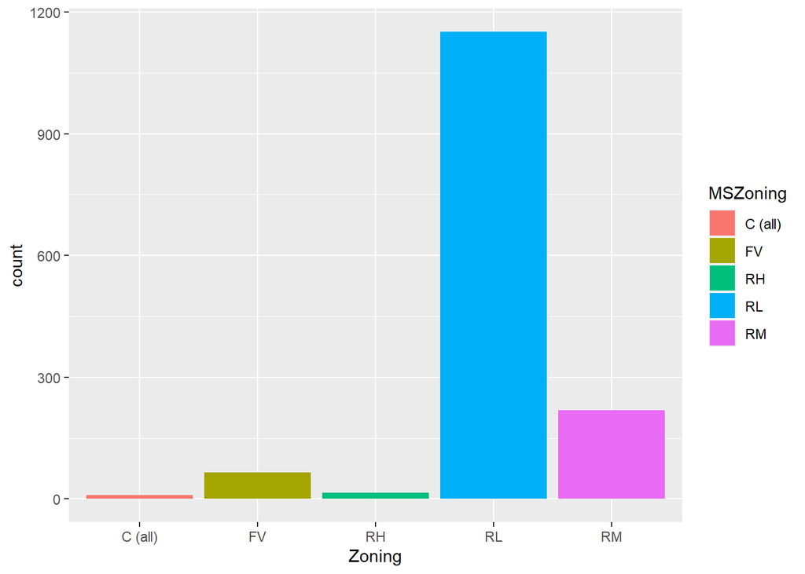

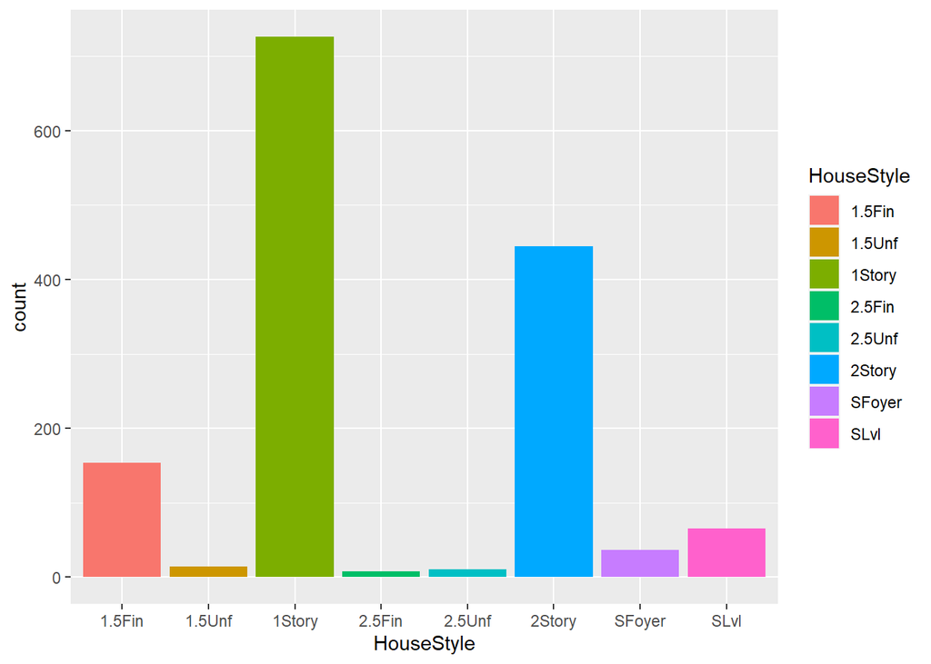

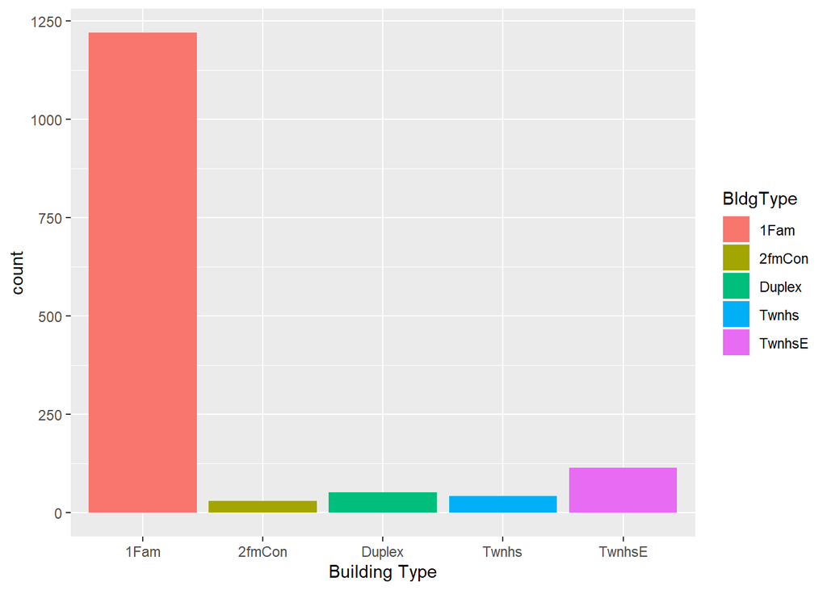

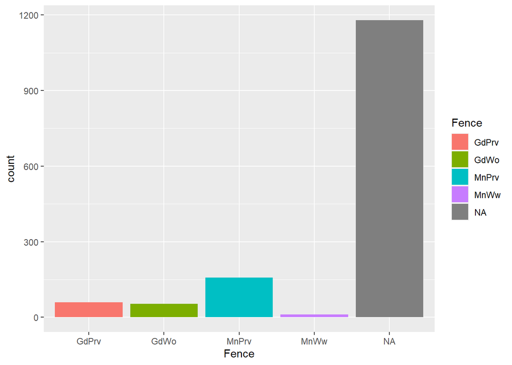

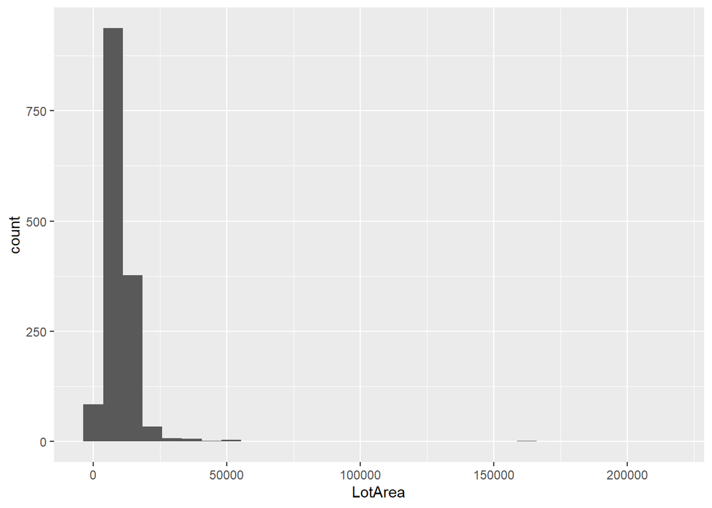

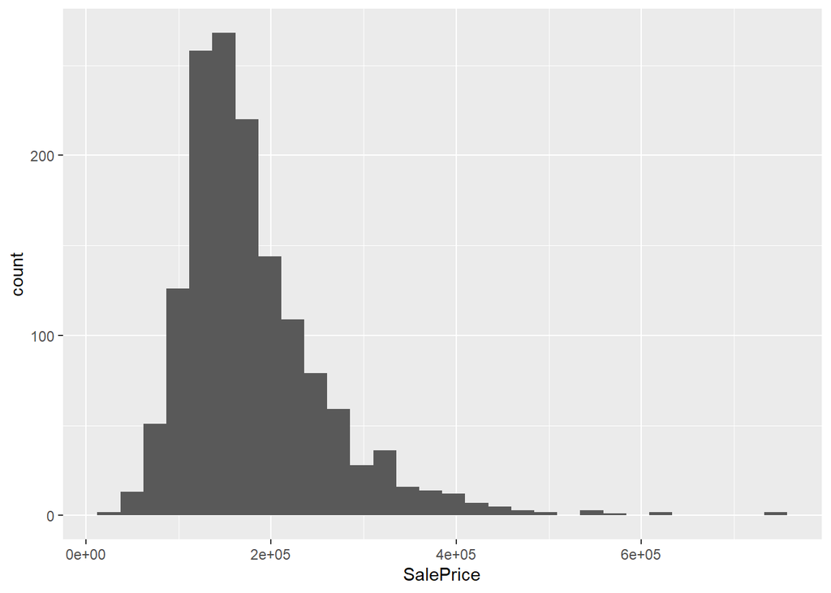

**box plots and scatter plots for initial analysis of data to also help with data cleanup steps**

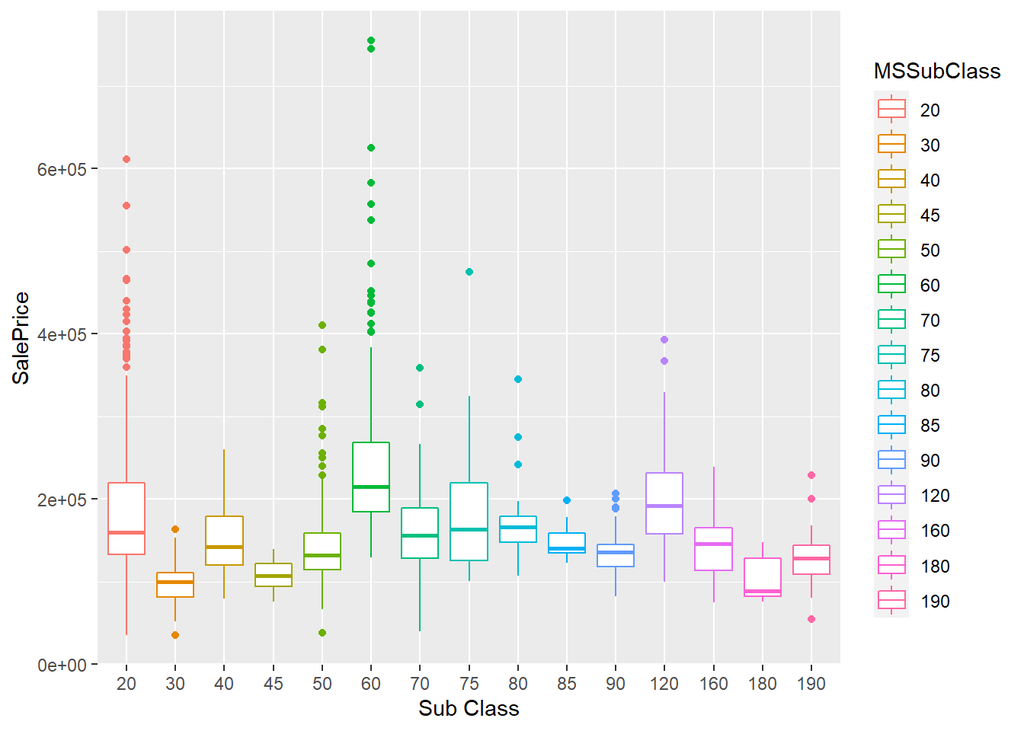

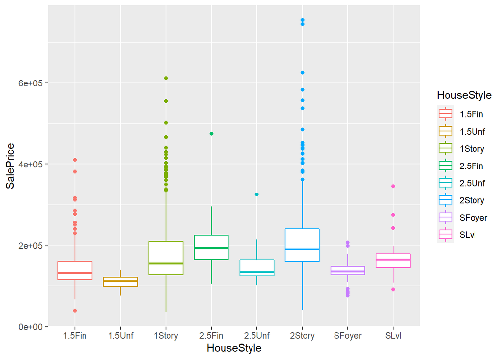

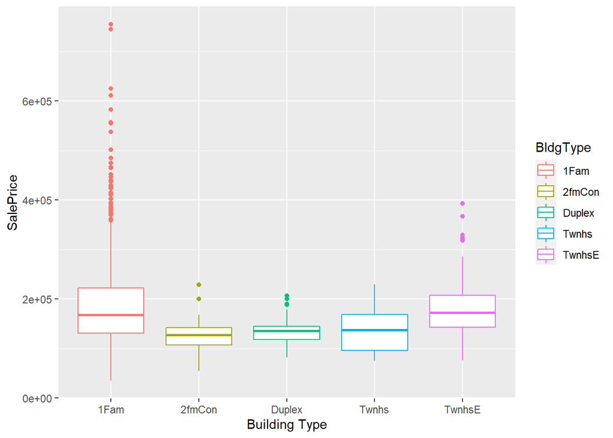

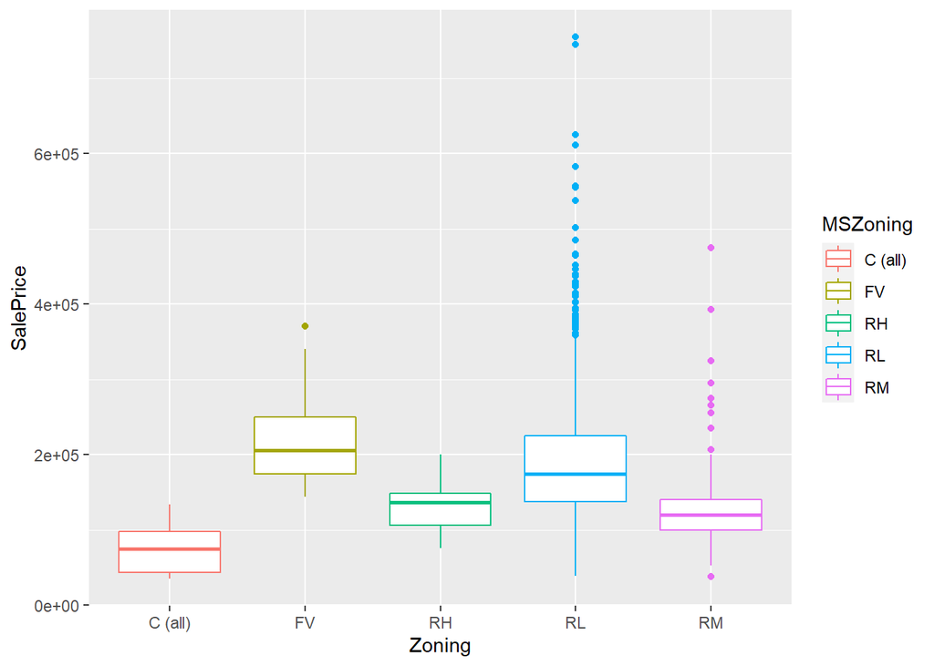

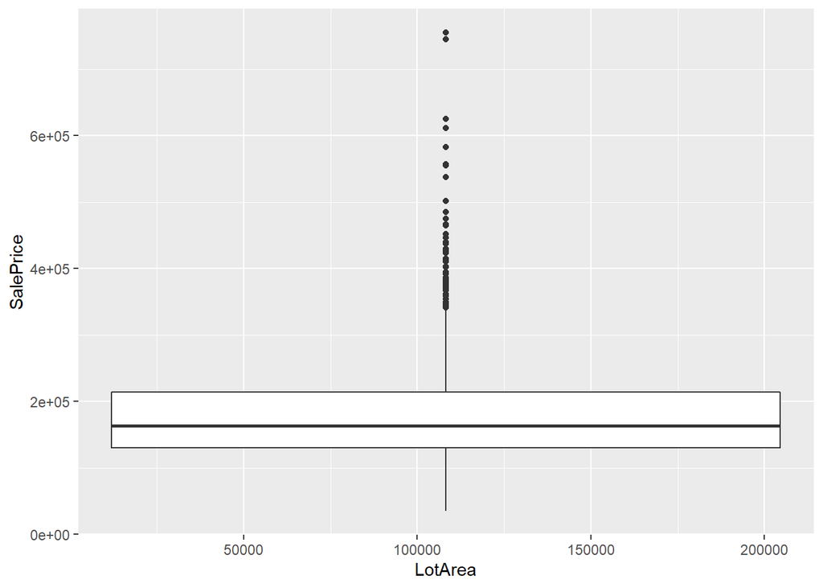

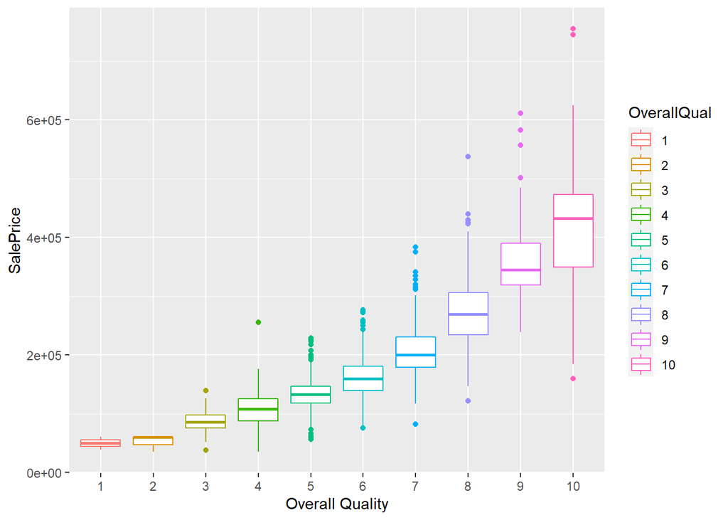

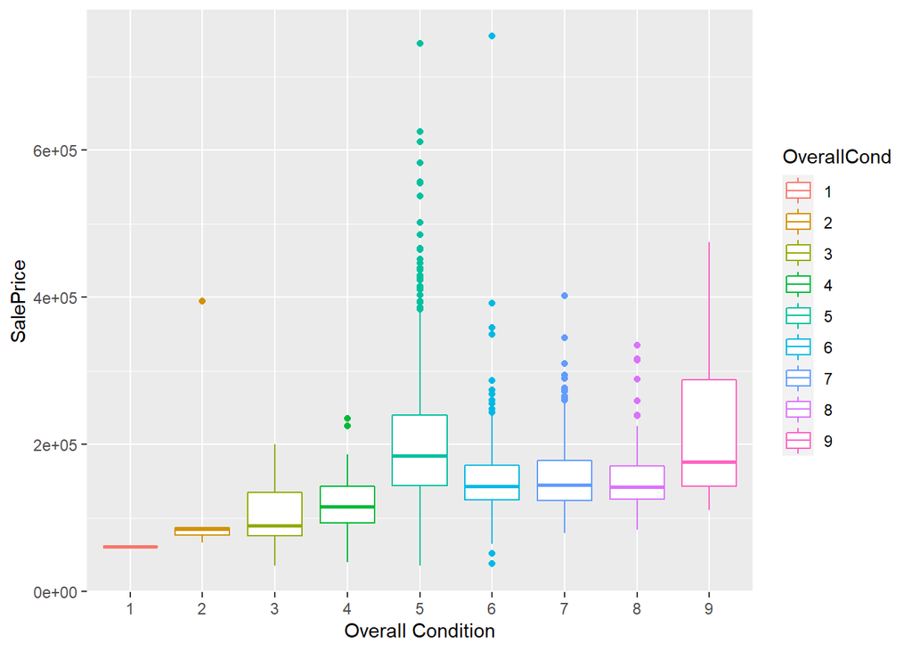

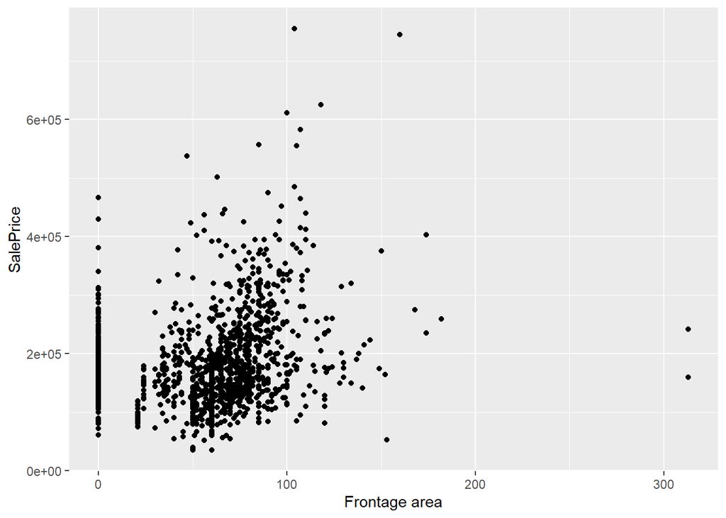

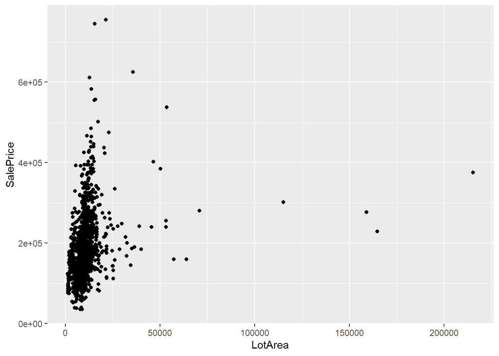

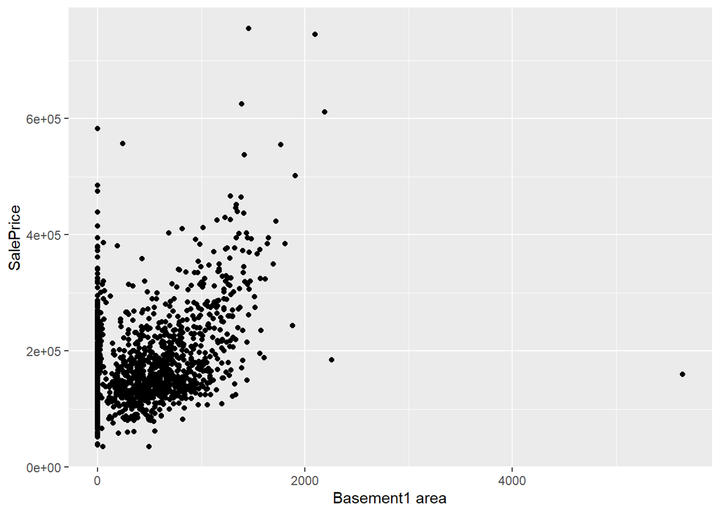

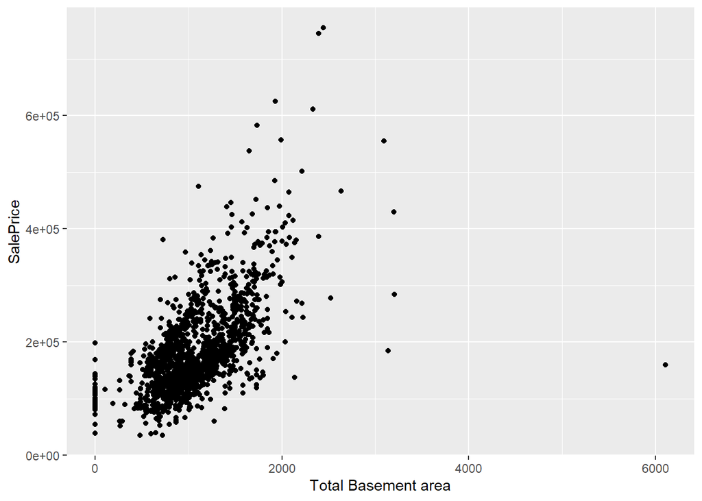

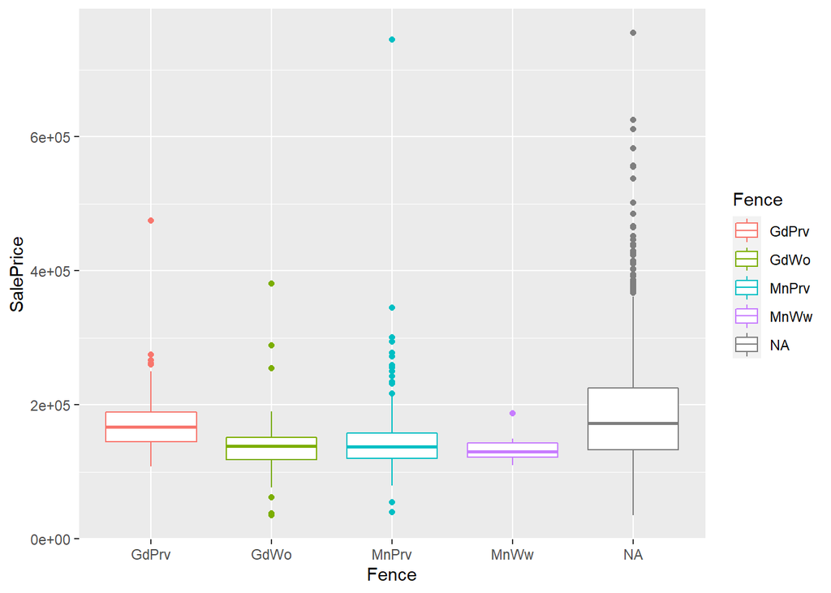

[5 more figures not shown]

**data cleanup / delete outliers and create data subset and summary() of the same subset**

> the variables selected in the current subset dataframe have been arrived at after multiple iterations of the model and fine tuning to add / drop variables from the subset to achieve better accuracy.

```
## 'data.frame':    1344 obs. of  39 variables:
##  $ MSSubClass   : Factor w/ 15 levels "20","30","40",..: 6 1 6 7 6 5 1 6 5 15 ...
##  $ MSZoning     : Factor w/ 5 levels "C (all)","FV",..: 4 4 4 4 4 4 4 4 5 4 ...
##  $ BldgType     : Factor w/ 5 levels "1Fam","2fmCon",..: 1 1 1 1 1 1 1 1 1 2 ...
##  $ HouseStyle   : Factor w/ 8 levels "1.5Fin","1.5Unf",..: 6 3 6 6 6 1 3 6 1 2 ...
##  $ LotConfig    : chr  "Inside" "FR2" "Inside" "Corner" ...
##  $ Neighborhood : chr  "CollgCr" "Veenker" "CollgCr" "Crawfor" ...
##  $ Condition1   : chr  "Norm" "Feedr" "Norm" "Norm" ...
##  $ Condition2   : chr  "Norm" "Norm" "Norm" "Norm" ...
##  $ Foundation   : chr  "PConc" "CBlock" "PConc" "BrkTil" ...
##  $ RoofStyle    : chr  "Gable" "Gable" "Gable" "Gable" ...
##  $ RoofMatl     : chr  "CompShg" "CompShg" "CompShg" "CompShg" ...
##  $ Exterior1st  : chr  "VinylSd" "MetalSd" "VinylSd" "Wd Sdng" ...
##  $ Exterior2nd  : chr  "VinylSd" "MetalSd" "VinylSd" "Wd Shng" ...
##  $ ExterQual    : chr  "Gd" "TA" "Gd" "TA" ...
```

[output cut: 25 more lines]

```
##    MSSubClass     MSZoning      BldgType      HouseStyle   LotConfig
##  20     :487   C (all):   9   1Fam  :1111   1Story :669   Length:1344
##  60     :260   FV     :  64   2fmCon:  28   2Story :401   Class :character
##  50     :137   RH     :  16   Duplex:  50   1.5Fin :145   Mode  :character
##  120    : 85   RL     :1040   Twnhs :  43   SLvl   : 61
##  30     : 67   RM     : 215   TwnhsE: 112   SFoyer : 37
##  160    : 63                                1.5Unf : 14
##  (Other):245                                (Other): 17
##  Neighborhood        Condition1         Condition2         Foundation
##  Length:1344        Length:1344        Length:1344        Length:1344
##  Class :character   Class :character   Class :character   Class :character
##  Mode  :character   Mode  :character   Mode  :character   Mode  :character
##
##
##
##
##   RoofStyle           RoofMatl         Exterior1st        Exterior2nd
##  Length:1344        Length:1344        Length:1344        Length:1344
##  Class :character   Class :character   Class :character   Class :character
##  Mode  :character   Mode  :character   Mode  :character   Mode  :character
##
##
##
##
##   ExterQual          HeatingQC          Electrical         LotFrontage
##  Length:1344        Length:1344        Length:1344        Min.   :  0.00
##  Class :character   Class :character   Class :character   1st Qu.: 42.00
##  Mode  :character   Mode  :character   Mode  :character   Median : 61.00
##                                                           Mean   : 56.19
##                                                           3rd Qu.: 77.00
##                                                           Max.   :182.00
##
##     LotArea       OverallQual   OverallCond    YearBuilt     YearRemodAdd
##  Min.   : 1300   5      :380   5      :742   Min.   :1872   Min.   :1950
##  1st Qu.: 7310   6      :359   6      :240   1st Qu.:1953   1st Qu.:1966
##  Median : 9164   7      :301   7      :194   Median :1972   Median :1992
##  Mean   : 9148   8      :145   8      : 70   Mean   :1970   Mean   :1984
##  3rd Qu.:11042   4      :112   4      : 51   3rd Qu.:2000   3rd Qu.:2003
##  Max.   :17920   9      : 20   3      : 24   Max.   :2009   Max.   :2010
##                  (Other): 27   (Other): 23
```

[output cut: 25 more lines]

```
##  Min.   :0.000   Min.   :0.000   Min.   : 2.000   Min.   :   0.0
##  1st Qu.:1.000   1st Qu.:2.000   1st Qu.: 5.000   1st Qu.: 308.0
##  Median :2.000   Median :3.000   Median : 6.000   Median : 464.5
##  Mean   :1.717   Mean   :2.854   Mean   : 6.381   Mean   : 454.0
##  3rd Qu.:2.000   3rd Qu.:3.000   3rd Qu.: 7.000   3rd Qu.: 572.0
##  Max.   :3.500   Max.   :8.000   Max.   :14.000   Max.   :1390.0
##
##    SalePrice
##  Min.   : 34900
##  1st Qu.:128000
##  Median :157700
##  Mean   :168855
##  3rd Qu.:200625
##  Max.   :340000
##
```

**Scatter Plots for relationship between Sale Price and some of the predictor variables**

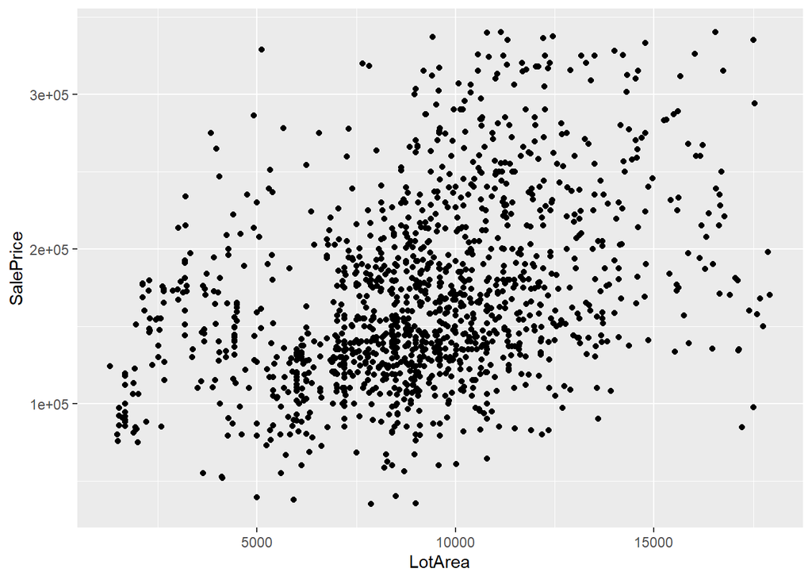

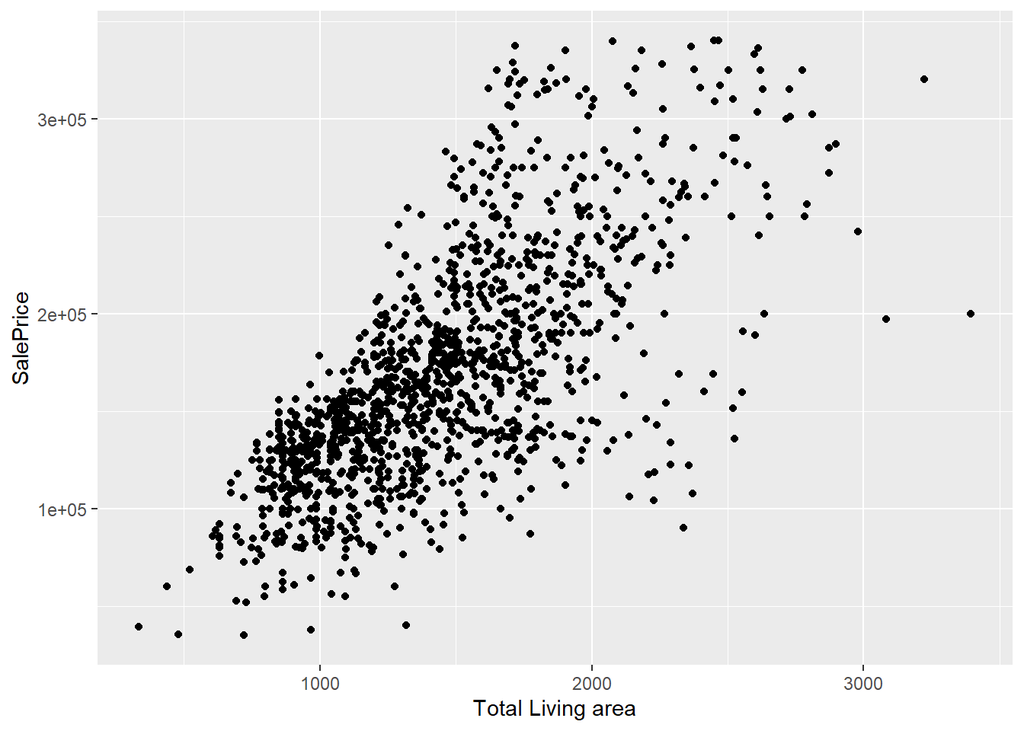

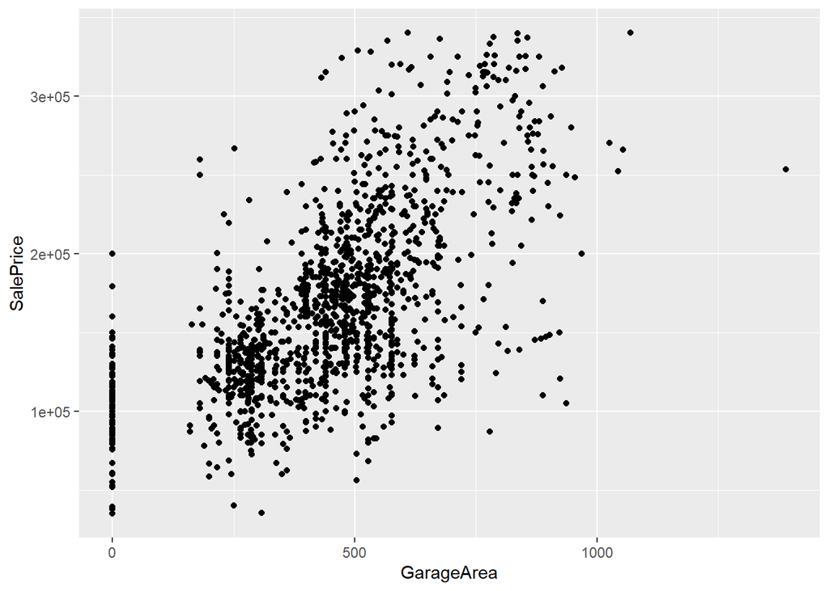